# Quiz Week 3

# Loading the Data

Let’s load the AOL Search Data Set (extracted from aol_search_data.zip):

# Cleaning the Data

## Tranforming column names to snake case

See how the current column names look like:

```
[1] "AnonID"    "Query"     "QueryTime" "ItemRank"  "ClickURL"
```

Function for transforming a string to snake case

Function for converting data frame result column names to snake case

Check that the column names have been transformed:

```
[1] "anon_id"    "query"      "query_time" "item_rank"  "click_url"
```

# Analyzing the Data

## Group the data by “user session”

A “user session” is defined by all events for a given user where there is no more than a thirty minute gap between events.

First, determine which rows belong to which sessions.

```
Observations: 3,558,411
Variables: 9
$ anon_id                 <int> 142, 142, 142, 142, 142, 142, 142, 142...
$ query                   <chr> "rentdirect.com", "www.prescriptionfor...
$ query_time              <dttm> 2006-03-01 07:17:12, 2006-03-12 12:31...
$ item_rank               <int> NA, NA, NA, NA, NA, NA, 1, NA, NA, NA,...
$ click_url               <chr> NA, NA, NA, NA, NA, NA, "http://www.we...
$ time_diff               <time> NA mins, 1.615390e+04 mins, 7.728383e...
$ new_session             <lgl> TRUE, TRUE, TRUE, FALSE, TRUE, FALSE, ...
$ session_sequence_number <dbl> 1, 2, 3, 3, 4, 4, 5, 6, 7, 7, 8, 9, 9,...
$ session_id              <chr> "142_1", "142_2", "142_3", "142_3", "1...
```

Now that we have the each query broken assigned to a unique session ID per user, we can summarize its statistics and gather data like number of searches, when the session started, when the session ended, session duration, number of clicks, mean rank of query, and mean number of search terms (separated by " “).

```
Observations: 1,069,200
Variables: 9
$ anon_id                  <int> 142, 142, 142, 142, 142, 142, 142, 14...
$ session_sequence_number  <dbl> 1, 2, 3, 4, 5, 6, 7, 8, 9, 10, 11, 12...
$ number_searches          <int> 1, 1, 2, 2, 1, 1, 2, 1, 2, 2, 4, 2, 1...
$ session_started_at       <dttm> 2006-03-01 07:17:12, 2006-03-12 12:3...
$ session_ended_at         <dttm> 2006-03-01 07:17:12, 2006-03-12 12:3...
$ session_length           <time> 0.0000000 mins, 0.0000000 mins, 0.26...
$ number_clicks            <int> 0, 0, 0, 0, 1, 0, 0, 0, 0, 1, 1, 0, 0...
$ mean_item_rank           <dbl> NA, NA, NA, NA, 1, NA, NA, NA, NA, NA...
$ mean_number_search_terms <dbl> 1, 1, 2, 2, 1, 1, 2, 1, 2, 2, 4, 2, 1...
```

# Plotting the session statistics

## Statistics by session

Distribution of session durations (histogram count)

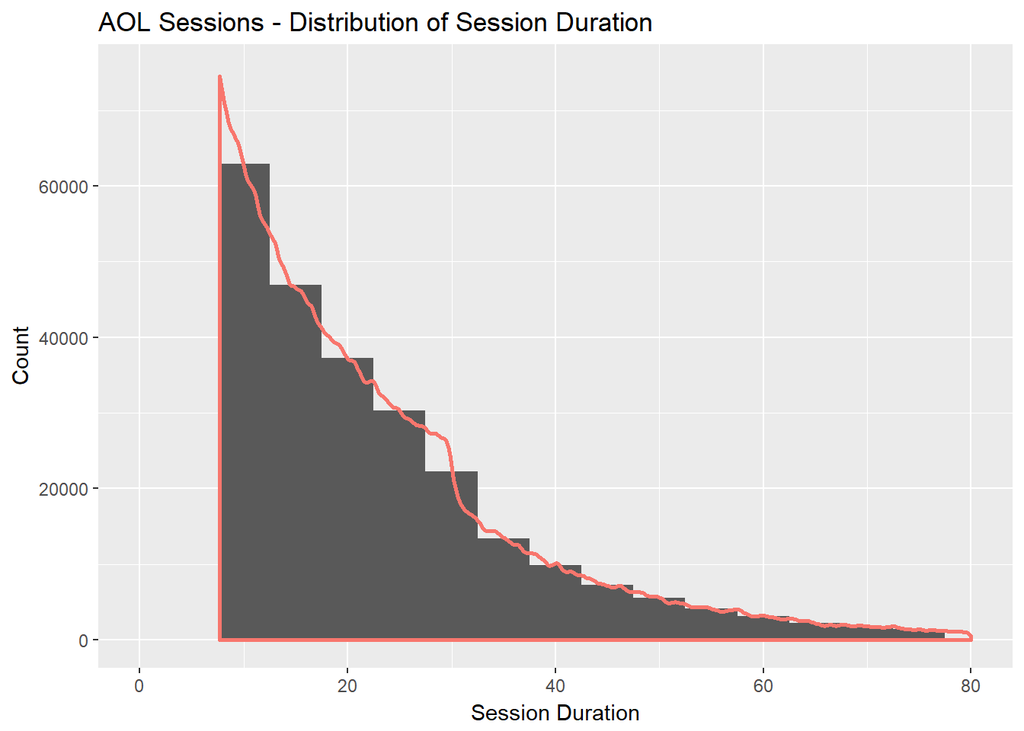

Distribution of the number of clicks per session (histogram count)

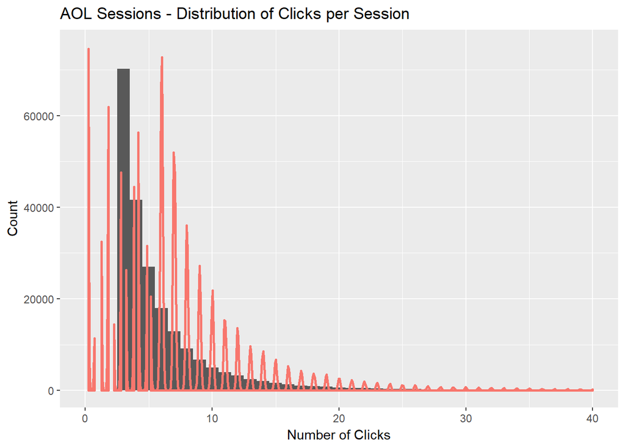

## Statistics by user

First, calculate the statistics by user

```
Observations: 65,516
Variables: 3
$ anon_id             <int> 142, 217, 993, 1268, 1326, 1337, 1410, 200...
$ sessions_count      <int> 18, 22, 3, 18, 25, 14, 9, 17, 50, 29, 32, ...
$ mean_session_length <time> 0.90462963 mins, 0.90378788 mins, 0.02777...
```

Distribution of the number of sessions by user (histogram count)

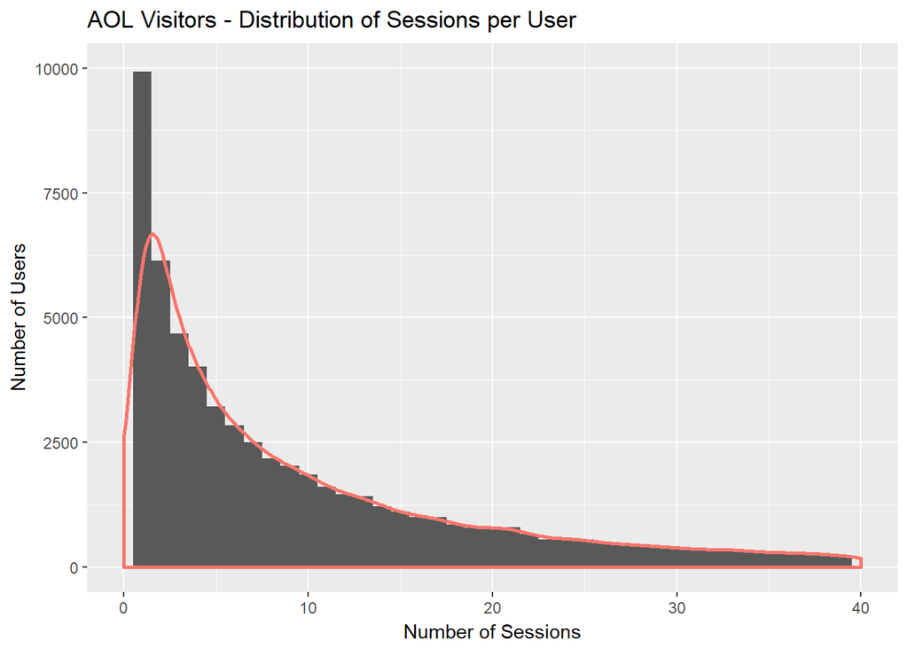

Distribution of the mean session duration by user (histogram count)

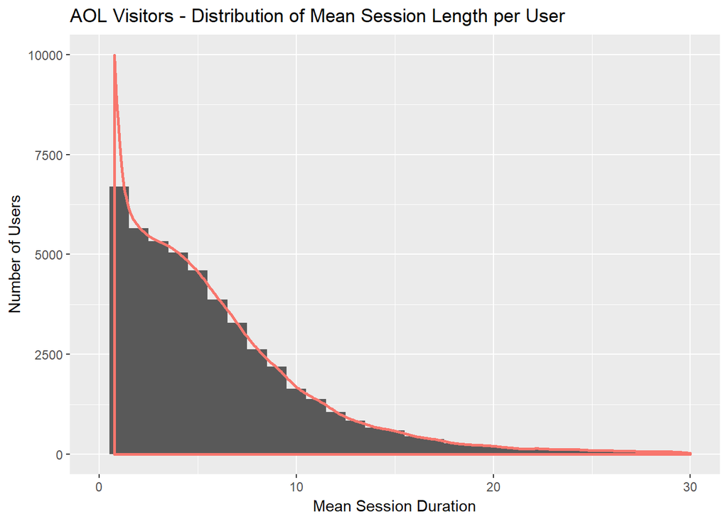

## Statistics by query_time (hour)

We will convert the query_time to its hour, then add this value as a column to the `user_searches` data frame,

There is now a new column that we can use to group the queries by the hour and determine stats for the queries by the hour.

```
Observations: 24
Variables: 3
$ query_time_hour <int> 0, 1, 2, 3, 4, 5, 6, 7, 8, 9, 10, 11, 12, 13, ...
$ query_count     <int> 136806, 92172, 56195, 36987, 26372, 26314, 377...
$ number_clicks   <int> 71020, 46765, 28600, 17943, 13590, 15052, 2104...
```

Number of queries during each hour

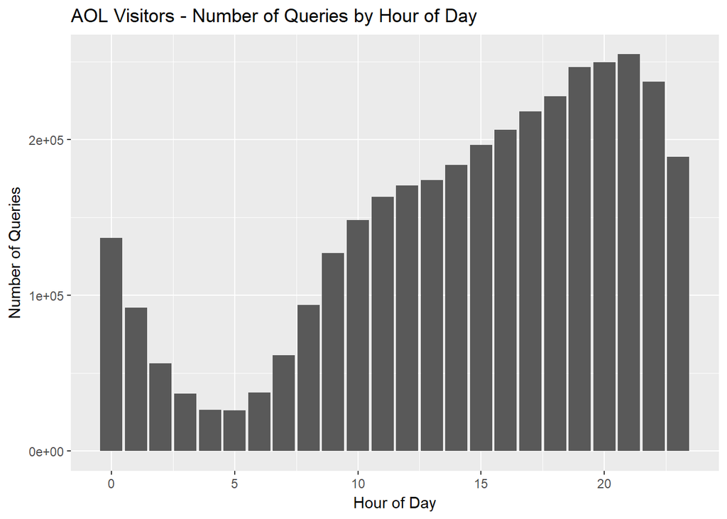

Number of clicks during each hour

[figure not shown]

For both queries and clicks, the minimum would occur around 4:00-5:00 and the maximum occurred around 21:00.

Use the nycflights13::flights to answer the following questions. Use diplyr pipes in all your answers.

1. Create two data frames, one consisting of 1000 observations, the other consisting of the 0.1% of the flights dataset.

```r
library(nycflights13)
library(dplyr)

f1000 <- sample_n(nycflights13::flights, 1000)
f0001 <- sample_frac(nycflights13::flights, 0.001)
```

2. Create a data frame that removes duplicate rows based on departure day and carriers only.

```r
new_df <- nycflights13::flights %>%
  distinct(day, carrier, .keep_all=TRUE)
```

3. Create a data frame from df1 consisting of only carrier and tailnum, create a data frame df2 consisting of all of the original variables in flights except carrier and tailnum.

```r
df1 <- select(nycflights13::flights, carrier, tailnum)
df2 <- select(nycflights13::flights, -matches("carrier", "tailnum"))

df1 <- nycflights13::flights %>%
  select(carrier, tailnum)
df2 <- nycflights13::flights %>%
  select(-carrier, -tailnum)
```

Select function can also be used to reorder fields in the dataframe.

4. Create a data frame df consisting of only the fields related to time.

```r
df <- nycflights13::flights %>%
  select(matches("time"))
```

Can use regular expressions as well.

5. Create a dataframe with flight number as the first column followed by the other columns in flights.

```r
df <- nycflights13::flights %>%
  select(flight, everything())
```

6. Create a data frame where the column tailnum is changed to tail_number.

```r
df <- nycflights13::flights %>%
  rename(tail_number = tailnum)
```

rename(new_Name=old_Name)

7. Create a data frame consisting of only flights originating from jfk airport and carrier is united airlines.

```r
df <- nycflights13::flights %>%
  filter(origin == "JFK" & carrier == "UA")
```

&& is bitwise and individualized element-wise comparison. Use commas instead of &

8. What is the median and mean arrival delay for all flights?

What is the median and mean arrival delay originating out of jfk by carrier?

```r
nycflights13::flights %>%
  summarise(mean_arr_delay = mean(arr_delay, na.rm=TRUE), median_arr_delay = median(arr_delay, na.rm=TRUE))
```

```
## # A tibble: 1 x 2
##   mean_arr_delay median_arr_delay
##            <dbl>            <dbl>
## 1       6.895377               -5
```

```r
nycflights13::flights %>%
  filter(origin == "JFK") %>%
  group_by(carrier) %>%
  summarise(mean_arr_delay = mean(arr_delay, na.rm=TRUE), median_arr_delay = median(arr_delay, na.rm=TRUE))
```

```
## # A tibble: 10 x 3
##    carrier mean_arr_delay median_arr_delay
##      <chr>          <dbl>            <dbl>
##  1      9E       8.843327               -7
##  2      AA       2.081250               -8
##  3      B6       8.893702               -3
##  4      DL      -2.379250              -11
##  5      EV      17.788839               -1
##  6      HA      -6.915205              -13
##  7      MQ      12.468704               -1
##  8      UA       2.510496               -6
##  9      US       2.114035               -4
## 10      VX       2.827722               -8
```

na.rm=TRUE means to ignore the NA values

9. What are the three days in a month with the lowest maximum departure delay, and what is it?

```r
nycflights13::flights %>%
  group_by(day) %>%
  summarise(maximum_departure = max(dep_delay, na.rm=TRUE)) %>%
  arrange(maximum_departure) %>%
  head(3)
```

```
## # A tibble: 3 x 2
##     day maximum_departure
##   <int>             <dbl>
## 1    25               420
## 2    29               420
## 3    30               437
```

top_n(-3) would work as well

10. Explain the difference in results between these two dplyr statements:

```r
nycflights13::flights %>%
  mutate(mean_dep_delay=mean(dep_delay, na.rm=TRUE))
```

```
## # A tibble: 336,776 x 20
##     year month   day dep_time sched_dep_time dep_delay arr_time
##    <int> <int> <int>    <int>          <int>     <dbl>    <int>
##  1  2013     1     1      517            515         2      830
##  2  2013     1     1      533            529         4      850
##  3  2013     1     1      542            540         2      923
##  4  2013     1     1      544            545        -1     1004
##  5  2013     1     1      554            600        -6      812
##  6  2013     1     1      554            558        -4      740
##  7  2013     1     1      555            600        -5      913
##  8  2013     1     1      557            600        -3      709
##  9  2013     1     1      557            600        -3      838
## 10  2013     1     1      558            600        -2      753
## # ... with 336,766 more rows, and 13 more variables: sched_arr_time <int>,
## #   arr_delay <dbl>, carrier <chr>, flight <int>, tailnum <chr>,
## #   origin <chr>, dest <chr>, air_time <dbl>, distance <dbl>, hour <dbl>,
## #   minute <dbl>, time_hour <dttm>, mean_dep_delay <dbl>
```

```r
flights %>%
  summarise(mean_dep_delay = mean(dep_delay, na.rm=TRUE))
```

```
## # A tibble: 1 x 1
##   mean_dep_delay
##            <dbl>
## 1       12.63907
```

The first statement adds another column to the data frame with the mean of departure delay, whereas the second statement creates a separate table that summarizes the data frame, and the only column is the mean of the departure delay.